# Lab notebook - Dec 2021-May 2022

Michael Jahn

23 November, 2023

# Preface

Lab notebook for December 2021 to May 2022. Previous lab books are in paper form. Low compexity lab data is directly added to this notebook and visualized. For this purpose, some R libraries are loaded.

```r
suppressPackageStartupMessages({
  library(tidyverse)
  library(lattice)
  library(latticeExtra)
  library(latticetools)
})
```

Set default experiments directory.

```r
dir_exp = "/media/michael/data/Scilifelab/Experiments/"
```

Convenience functions for different charts.

```r
plot_barchart <- function(df, xvar, yvar, xlim = NULL, ylim = NULL, offset = NULL, xrot = 0, ...) {
  scales = list(alternating = FALSE, x = list(limits = xlim, rot = xrot), y = list(limits = ylim))
  if (!is.factor(df[[xvar]])) df <- mutate(df, across(matches(xvar), fct_inorder))
  xyplot(get(yvar) ~ get(xvar), df,
    par.settings = custom.colorblind(), fill = "white", lwd = 2,
    xlab = xvar, ylab = yvar, offset = offset,
    scales = scales,
    panel = function(x, y, ...) {
      panel.grid(h = -1, v = -1, col = grey(0.9))
      panel.barplot(x, y, ...)
      panel.stripplot(x, y, cex = 0.6, jitter.data = TRUE,
        horizontal = FALSE, alpha = 0.5, ...)
      panel.pvalue(x, y, ...)
    }
  )
}

plot_OD <- function(df, groups = NULL, ...) {
  xyplot(od_corr ~ batchtime_h | factor(sample, unique(sample)),
    filter(df, od_led == 720), type = "l", lwd = 2,
    groups = {if (is.null(groups)) NULL else {get(groups)}},
    as.table = TRUE, between = list(x = 0.5, y = 0.5),
    ylab = expression("OD"[600]),
    par.settings = custom.colorblind(),
    scales = list(alternating = FALSE),
    panel = function(x, y, ...) {
      panel.grid(h = -1, v = -1, col = grey(0.9))
      panel.xyplot(x, y, ...)
    }, ...
  )
}

plot_MU <- function(df, groups = NULL, ...) {
  xyplot(value ~ batchtime_h | factor(sample, unique(sample)),
    df, type = "l", lwd = 2,
    groups = {if (is.null(groups)) NULL else {get(groups)}},
    as.table = TRUE, between = list(x = 0.5, y = 0.5),
    ylab = expression("µ [h"^-1*"]"),
    par.settings = custom.colorblind(),
    scales = list(alternating = FALSE),
    panel = function(x, y, ...) {
      panel.grid(h = -1, v = -1, col = grey(0.9))
      panel.xyplot(x, y, ...)
    }, ...
  )
}
```

# 2021-12-03

## Shipment of TnLib samples to JBEI

- samples were picked up from a courier from YSDS (15:00)
- content: 4 x 1 mL aliquots of TnLib, -80*C
- sent on 10-20 kg dry ice, estimated delivery in 4 days
- tested viability by plating 10 µL of 1:10, 1:100, 1:1000 dilutions
- viability was higher than expected, around 5x10^4 CFU/µL (before freezing!)
- colony morphology was 100% *Ralstonia*

## MC2 cultivation of hox/hyp mutants

# 2021-12-06

## Results MC2 cultivation of hox/hyp mutants

- finished second batch cultivation: not useful to determine yield/growth rate differences because cells were in different growth states or density when starting (just filled up new medium, instead of restarting properly)
- measured DCW, yield and OD/growth rate of first batch growth experiment, see results below

**Table: final DCW and biomass yield of 1st batch cultivation**

```r
df_DCW_20211206 <- data.frame(
    sample = rep(c("WT", "hoxA", "hypX", "hypB"), each = 2),
    tube_weight_mg = c(991.43, 999.80, 991.03, 1000.94, 995.92, 990.10, 998.16, 1013.17),
    total_weight_mg = c(1024.33, 1034.47, 1024.12, 1034.80, 1025.28, 1019.30, 1027.56, 1041.40),
    final_OD600 = c(0.496, 0.548, 0.480, 0.513, 0.480, 0.452, 0.473, 0.461)
  ) %>%
  mutate(
    DCW_mg = total_weight_mg - tube_weight_mg,
    yield_gDCW_gFRC = DCW_mg/(1000 * 2.0 * 0.05)
  )

df_DCW_20211206
```

| sample | tube_weight_mg | total_weight_mg | final_OD600 | DCW_mg | yield_gDCW_gFRC |
| --- | --- | --- | --- | --- | --- |
| WT | 991.43 | 1024.33 | 0.496 | 32.90 | 0.3290 |
| WT | 999.80 | 1034.47 | 0.548 | 34.67 | 0.3467 |
| hoxA | 991.03 | 1024.12 | 0.480 | 33.09 | 0.3309 |
| hoxA | 1000.94 | 1034.80 | 0.513 | 33.86 | 0.3386 |
| hypX | 995.92 | 1025.28 | 0.480 | 29.36 | 0.2936 |
| hypX | 990.10 | 1019.30 | 0.452 | 29.20 | 0.2920 |
| hypB | 998.16 | 1027.56 | 0.473 | 29.40 | 0.2940 |
| hypB | 1013.17 | 1041.40 | 0.461 | 28.23 | 0.2823 |

**Figure: biomass yield of 1st batch cultivation**

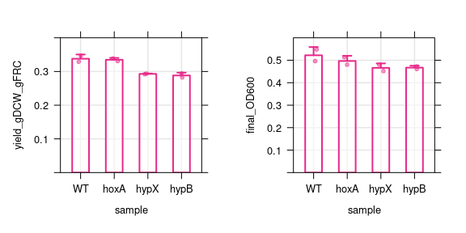

```r
plot_barchart(df_DCW_20211206, xvar = "sample", yvar = "yield_gDCW_gFRC", ylim = c(0, 0.4)) %>%
  print(split = c(1,1,2,1), more = TRUE)
plot_barchart(df_DCW_20211206, xvar = "sample", yvar = "final_OD600", ylim = c(0, 0.6)) %>%
  print(split = c(2,1,2,1), more = TRUE)
```

**Figure: comparison of growth rate for MC batch cultivation**

```r
df_OD_20211206 <- read_csv(paste0(dir_exp, "20211201_MC2_batch_mutants/20211201_MC2_measurements.csv"),
  show_col_types = FALSE, col_select = -1) %>%
  mutate(sample = case_when(channel_id %in% 1:2 ~ "WT", channel_id %in% 3:4 ~ "hoxA",
    channel_id %in% 5:6 ~ "hypX", channel_id %in% 7:8 ~ "hypB")) %>%
  group_by(sample, batchtime_h) %>% mutate(replicate = 1:n())
df_mu_20211206 <- read_csv(paste0(dir_exp, "20211201_MC2_batch_mutants/MU.csv"),
  show_col_types = FALSE, col_select = -1) %>%
  mutate(sample = case_when(channel_id %in% 1:2 ~ "WT", channel_id %in% 3:4 ~ "hoxA",
    channel_id %in% 5:6 ~ "hypX", channel_id %in% 7:8 ~ "hypB")) %>%
  group_by(sample, batchtime_h) %>% mutate(replicate = 1:n())
```

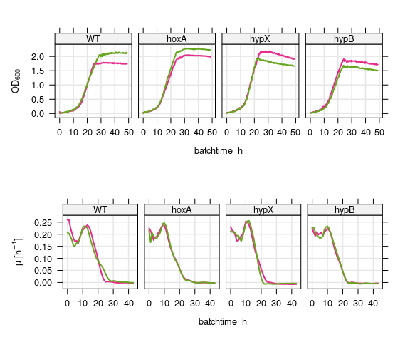

```r
print(plot_OD(df_OD_20211206, groups = "replicate", layout = c(4,1)), split = c(1,1,1,2), more = TRUE)
print(plot_MU(df_mu_20211206, groups = "replicate", layout = c(4,1)), split = c(1,2,1,2), more = TRUE)
```

**Direct comparison of maximum growth rate**

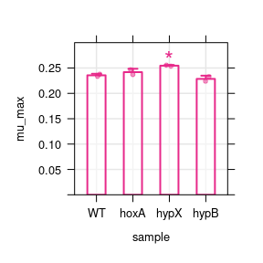

```r
df_mu_20211206 %>% filter(batchtime_h > 5) %>%
  group_by(sample, channel_id) %>%
  summarize(mu_max = max(value), .groups = "drop") %>%
  arrange(channel_id) %>%
  plot_barchart(xvar = "sample", yvar = "mu_max", ylim = c(0, 0.3), offset = 0.05)
```

**Conclusion**

- growth and/or yield difference between WT and hydrogenase mutants seems to be marginal
- plate reader experiments gave hints that mutants *could* grow faster, but as of yet inconclusive
- minimal medium stock that was used for MC showed cloudiness over night –> contamination
- discarded MM, prepared fresh medium, need to repeat MC experiment

## Preparations to redo MC2 cultivation of hox/hyp mutants

- goal: get more growth rate/yield data, start with lower OD to have adaptation phase happening early during cultivation, and optimally adapted cells in exp. phase
- started precultures for WT, hoxA, hypX, hypB1, 5 mL fresh MM + 2 g/L Frc
- prepared and autoclaved fresh set of reactor tubes

# 2021-12-08

## Redo experiment batch growth of hox/hyp mutants

- repetition of previous experiment from 2021-12-03
- started MC2 with 4 strains, 2 biological replicates
- fresh MM + 2 g/L Frc, + 1 g/L NH4Cl
- aeration: 100 mL/min for all tubes
- temp = 30*C
- t_start = 11:00
- precultures:

```r
tibble(
    strain = c("WT", "hoxA", "hypX", "hypB"),
    OD600_diluted = c(0.527, 0.620, 0.612, 0.528)
  ) %>%
  mutate(
    OD600 = OD600_diluted*4,
    V_for_OD_0.005 = 0.005/OD600,
    V_for_50_mL = V_for_OD_0.005*50
  )
```

| strain | OD600_diluted | OD600 | V_for_OD_0.005 | V_for_50_mL |
| --- | --- | --- | --- | --- |
| WT | 0.527 | 2.108 | 0.002371917 | 0.1185958 |
| hoxA | 0.620 | 2.480 | 0.002016129 | 0.1008065 |
| hypX | 0.612 | 2.448 | 0.002042484 | 0.1021242 |
| hypB | 0.528 | 2.112 | 0.002367424 | 0.1183712 |

# 2021-12-10

## Results MC2 cultivation of hox/hyp mutants

- starting with lower OD was a useful strategy: longer exp growth phase
- contrary to previous results, hox A did not grow faster but had longer log phase (preculture old?)
- measured DCW, yield and OD/growth rate

**Table: final DCW and biomass yield of 2nd batch cultivation**

```r
df_DCW_20211208 <- data.frame(
    sample = rep(c("WT", "hoxA", "hypX", "hypB"), each = 2),
    tube_weight_mg = c(1001.09, 1001.16, 995.67, 999.15, 1004.55, 996.51, 1000.24, 1001.17),
    total_weight_mg = c(1042.51, 1042.32, 1036.17, 1039.34, 1048.91, 1039.44, 1038.18, 1038.96)
  ) %>%
  mutate(
    DCW_mg = total_weight_mg - tube_weight_mg,
    yield_gDCW_gFRC = DCW_mg/(1000 * 2.0 * 0.05)
  )

df_DCW_20211208
```

| sample | tube_weight_mg | total_weight_mg | DCW_mg | yield_gDCW_gFRC |
| --- | --- | --- | --- | --- |
| WT | 1001.09 | 1042.51 | 41.42 | 0.4142 |
| WT | 1001.16 | 1042.32 | 41.16 | 0.4116 |
| hoxA | 995.67 | 1036.17 | 40.50 | 0.4050 |
| hoxA | 999.15 | 1039.34 | 40.19 | 0.4019 |
| hypX | 1004.55 | 1048.91 | 44.36 | 0.4436 |
| hypX | 996.51 | 1039.44 | 42.93 | 0.4293 |
| hypB | 1000.24 | 1038.18 | 37.94 | 0.3794 |
| hypB | 1001.17 | 1038.96 | 37.79 | 0.3779 |

**Comparison of growth rate for MC batch cultivation**

```r
df_OD_20211208 <- read_csv(paste0(dir_exp, "20211208_MC2_batch_mutants/20211208_MC2_measurements.csv"),
  show_col_types = FALSE, col_select = -1) %>% filter(od_led == 720) %>%
  mutate(sample = case_when(channel_id %in% 1:2 ~ "WT", channel_id %in% 3:4 ~ "hoxA",
    channel_id %in% 5:6 ~ "hypX", channel_id %in% 7:8 ~ "hypB")) %>%
  group_by(sample, batchtime_h) %>% mutate(replicate = 1:n())
df_mu_20211208 <- read_csv(paste0(dir_exp, "20211208_MC2_batch_mutants/MU.csv"),
  show_col_types = FALSE, col_select = -1) %>%
  mutate(sample = case_when(channel_id %in% 1:2 ~ "WT", channel_id %in% 3:4 ~ "hoxA",
    channel_id %in% 5:6 ~ "hypX", channel_id %in% 7:8 ~ "hypB")) %>%
  group_by(sample, batchtime_h) %>% mutate(replicate = 1:n()) %>%
  filter(value <= 0.4)
```

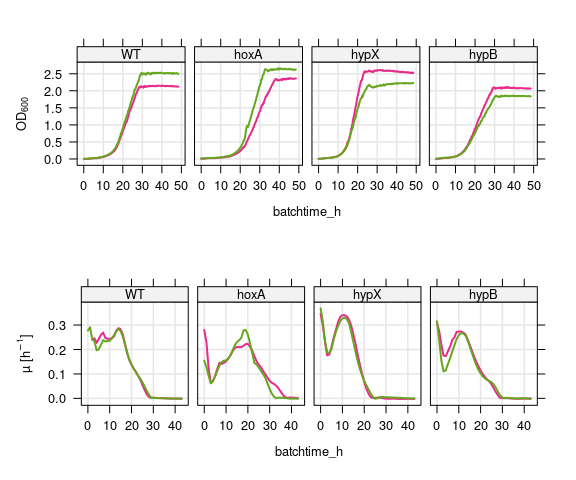

```r
print(plot_OD(df_OD_20211208, groups = "replicate", layout = c(4,1)), split = c(1,1,1,2), more = TRUE)
print(plot_MU(df_mu_20211208, groups = "replicate", layout = c(4,1)), split = c(1,2,1,2), more = TRUE)
```

**Comparison of maximum growth rate and yield**

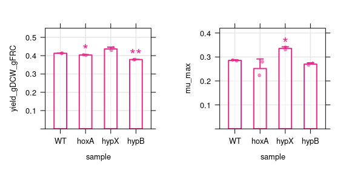

```r
plot_barchart(df_DCW_20211208, "sample", "yield_gDCW_gFRC", ylim = c(0, 0.55), offset = 0.1) %>%
  print(position = c(0,0,0.5,1), more = TRUE)

df_mu_20211208 %>% filter(batchtime_h > 5) %>%
  group_by(sample, channel_id) %>%
  summarize(mu_max = max(value), .groups = "drop") %>%
  arrange(channel_id) %>%
  plot_barchart("sample", "mu_max", ylim = c(0, 0.42), offset = 0.07) %>%
  print(position = c(0.5,0,1,1), more = TRUE)
```